# hw6_ss7636

2025-11-27

## Question 1

```r
homicide =
 read_csv("homicide-data.csv", na = c("NA",".", "")) |>
  janitor :: clean_names()
homicide
```

```
## # A tibble: 52,179 × 12
##    uid        reported_date victim_last  victim_first victim_race victim_age
##    <chr>              <dbl> <chr>        <chr>        <chr>       <chr>
##  1 Alb-000001      20100504 GARCIA       JUAN         Hispanic    78
##  2 Alb-000002      20100216 MONTOYA      CAMERON      Hispanic    17
##  3 Alb-000003      20100601 SATTERFIELD  VIVIANA      White       15
##  4 Alb-000004      20100101 MENDIOLA     CARLOS       Hispanic    32
##  5 Alb-000005      20100102 MULA         VIVIAN       White       72
##  6 Alb-000006      20100126 BOOK         GERALDINE    White       91
##  7 Alb-000007      20100127 MALDONADO    DAVID        Hispanic    52
##  8 Alb-000008      20100127 MALDONADO    CONNIE       Hispanic    52
##  9 Alb-000009      20100130 MARTIN-LEYVA GUSTAVO      White       56
## 10 Alb-000010      20100210 HERRERA      ISRAEL       Hispanic    43
## # ℹ 52,169 more rows
## # ℹ 6 more variables: victim_sex <chr>, city <chr>, state <chr>, lat <dbl>,
## #   lon <dbl>, disposition <chr>
```

```r
homicide_city_state =
  homicide |>
  mutate(
    city_state = paste(city, state, sep = ", ")
  ) |>
  mutate(
    unsolved = disposition %in% c("Closed without arrest", "Open/No arrest")
  ) |>
  mutate(solved_bin = ifelse(unsolved == TRUE, 0, 1)) |>
  filter(!(city_state %in% c("Dallas, TX",
                             "Phoenix, AZ",
                             "Kansas City, MO",
                             "Tulsa, AL"))) |>
  filter(victim_race %in% c("White", "Black")) |>
  mutate(victim_age = as.numeric(victim_age))
homicide_city_state
```

```
## # A tibble: 39,693 × 15
##    uid        reported_date victim_last  victim_first victim_race victim_age
##    <chr>              <dbl> <chr>        <chr>        <chr>            <dbl>
##  1 Alb-000003      20100601 SATTERFIELD  VIVIANA      White               15
##  2 Alb-000005      20100102 MULA         VIVIAN       White               72
##  3 Alb-000006      20100126 BOOK         GERALDINE    White               91
##  4 Alb-000009      20100130 MARTIN-LEYVA GUSTAVO      White               56
##  5 Alb-000012      20100218 LUJAN        KEVIN        White               NA
##  6 Alb-000016      20100308 GRAY         STEFANIA     White               43
##  7 Alb-000018      20100323 DAVID        LARRY        White               52
##  8 Alb-000019      20100402 BRITO        ELIZABETH    White               22
##  9 Alb-000021      20100423 KING         TEVION       Black               15
## 10 Alb-000022      20100423 BOYKIN       CEDRIC       Black               25
## # ℹ 39,683 more rows
## # ℹ 9 more variables: victim_sex <chr>, city <chr>, state <chr>, lat <dbl>,
## #   lon <dbl>, disposition <chr>, city_state <chr>, unsolved <lgl>,
## #   solved_bin <dbl>
```

```r
baltimore = homicide_city_state |>
  filter(city_state == "Baltimore, MD")


fit = glm(
  solved_bin ~ victim_age + victim_sex + victim_race, data = baltimore,  family = binomial(link = "logit")
)
tidy_fit = broom::tidy(fit, conf.int = TRUE, exponentiate = TRUE)

tidy_fit
```

```
## # A tibble: 4 × 7
##   term             estimate std.error statistic  p.value conf.low conf.high
##   <chr>               <dbl>     <dbl>     <dbl>    <dbl>    <dbl>     <dbl>
## 1 (Intercept)         1.36    0.171        1.81 7.04e- 2    0.976     1.91
## 2 victim_age          0.993   0.00332     -2.02 4.30e- 2    0.987     1.000
## 3 victim_sexMale      0.426   0.138       -6.18 6.26e-10    0.324     0.558
## 4 victim_raceWhite    2.32    0.175        4.82 1.45e- 6    1.65      3.28
```

```r
tidy_fit |>
  filter(term == "victim_sexMale")
```

```
## # A tibble: 1 × 7
##   term           estimate std.error statistic  p.value conf.low conf.high
##   <chr>             <dbl>     <dbl>     <dbl>    <dbl>    <dbl>     <dbl>
## 1 victim_sexMale    0.426     0.138     -6.18 6.26e-10    0.324     0.558
```

The adjusted odds ratio for a homicide being solved comparing male to female victims, holding age and race constant, was OR = 0.426. The confidence interval is (0.324, 0.558).

```r
city_models = homicide_city_state |>
  group_by(city_state) |>
  nest() |>
  mutate(
    fit = map(data, ~ glm(
      solved_bin ~ victim_age + victim_sex + victim_race,
      data = .x,
      family = binomial(link = "logit")
    )),
    tidy_fit = map(fit, ~ broom::tidy(.x, conf.int = TRUE, exponentiate = TRUE))
  ) |>
  select(city_state, tidy_fit) |>
  unnest(tidy_fit) |>
  filter(term == "victim_sexMale")
city_models
```

```
## # A tibble: 47 × 8
## # Groups:   city_state [47]
##    city_state    term  estimate std.error statistic   p.value conf.low conf.high
##    <chr>         <chr>    <dbl>     <dbl>     <dbl>     <dbl>    <dbl>     <dbl>
##  1 Albuquerque,… vict…    1.77      0.385  1.48     1.39 e- 1    0.825     3.76
##  2 Atlanta, GA   vict…    1.00      0.194  0.000397 1.000e+ 0    0.680     1.46
##  3 Baltimore, MD vict…    0.426     0.138 -6.18     6.26 e-10    0.324     0.558
##  4 Baton Rouge,… vict…    0.381     0.306 -3.15     1.65 e- 3    0.204     0.684
##  5 Birmingham, … vict…    0.870     0.212 -0.657    5.11 e- 1    0.571     1.31
##  6 Boston, MA    vict…    0.674     0.326 -1.21     2.26 e- 1    0.353     1.28
##  7 Buffalo, NY   vict…    0.521     0.299 -2.18     2.90 e- 2    0.288     0.936
##  8 Charlotte, NC vict…    0.884     0.236 -0.524    6.00 e- 1    0.551     1.39
##  9 Chicago, IL   vict…    0.410     0.102 -8.77     1.86 e-18    0.336     0.501
## 10 Cincinnati, … vict…    0.400     0.269 -3.41     6.49 e- 4    0.231     0.667
## # ℹ 37 more rows
```

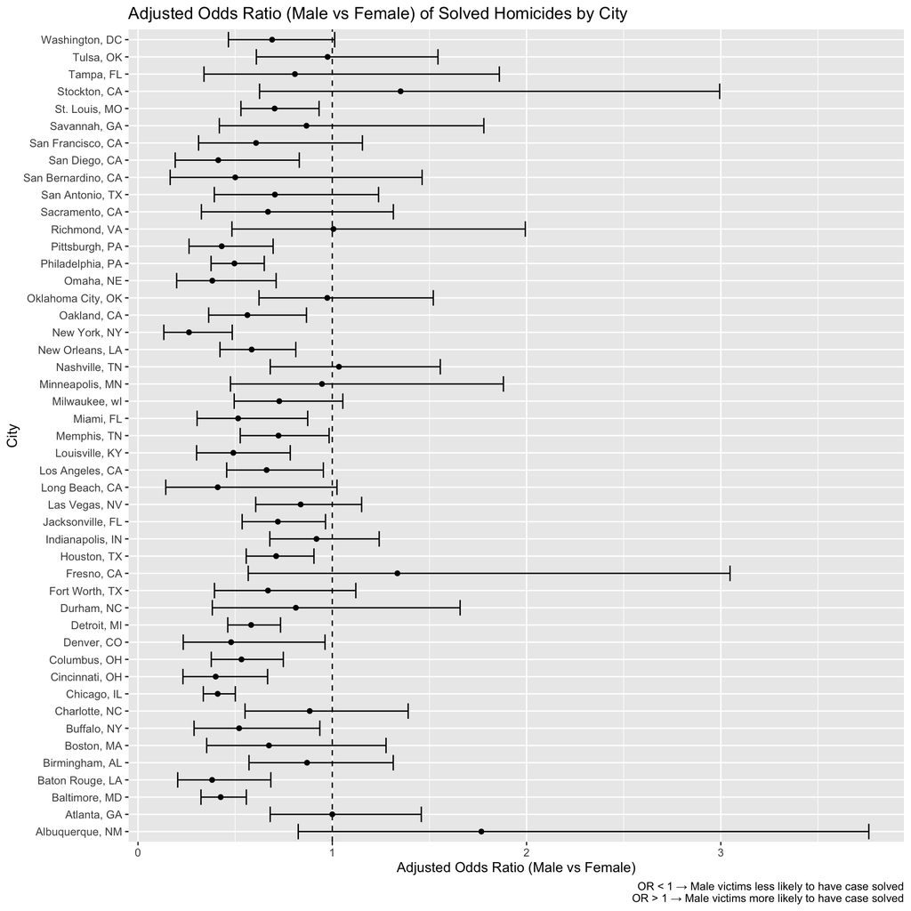

```r
city_models_plot = ggplot(city_models |>
         mutate(city_state = fct_reorder(city_state, estimate)),
       aes(x = city_state, y = estimate)) +
  geom_point() +
  geom_errorbar(aes(ymin = conf.low, ymax = conf.high)) +
  geom_hline(yintercept = 1, linetype = "dashed") +
  coord_flip() +
  labs(
    title = "Adjusted Odds Ratio (Male vs Female) of Solved Homicides by City",
    x = "City",
    y = "Adjusted Odds Ratio (Male vs Female)",
    caption = "OR < 1 → Male victims less likely to have case solved\nOR > 1 → Male victims more likely to have case solved"
  )

city_models_plot
```

The plot shows the odds that a homicide is solved for male vs female victims, holding age and race constant for each city and state. Many cities and states have the OR < 1, meaning male victims are less likely to have their cases solved. Notable cities would be Baton Rouge, LA, Cincinnati, OH, Long Beach, CA, New York, NY, and San Diego, CA. A few cities have OR = 1, such as Atlanta, GA and Nashville, TN. Very few cities have OR > 1. Some include Alburquerque, NM, Fresno, CA, and Stockton, CA.

## Question 2

```r
library(p8105.datasets)
data("weather_df")

weather_df
```

```
## # A tibble: 2,190 × 6
##    name           id          date        prcp  tmax  tmin
##    <chr>          <chr>       <date>     <dbl> <dbl> <dbl>
##  1 CentralPark_NY USW00094728 2021-01-01   157   4.4   0.6
##  2 CentralPark_NY USW00094728 2021-01-02    13  10.6   2.2
##  3 CentralPark_NY USW00094728 2021-01-03    56   3.3   1.1
##  4 CentralPark_NY USW00094728 2021-01-04     5   6.1   1.7
##  5 CentralPark_NY USW00094728 2021-01-05     0   5.6   2.2
##  6 CentralPark_NY USW00094728 2021-01-06     0   5     1.1
##  7 CentralPark_NY USW00094728 2021-01-07     0   5    -1
##  8 CentralPark_NY USW00094728 2021-01-08     0   2.8  -2.7
##  9 CentralPark_NY USW00094728 2021-01-09     0   2.8  -4.3
## 10 CentralPark_NY USW00094728 2021-01-10     0   5    -1.6
## # ℹ 2,180 more rows
```

```r
fit0 = lm(tmax ~ tmin + prcp, data = weather_df)
broom::glance(fit0)
```

```
## # A tibble: 1 × 12
##   r.squared adj.r.squared sigma statistic p.value    df logLik    AIC    BIC
##       <dbl>         <dbl> <dbl>     <dbl>   <dbl> <dbl>  <dbl>  <dbl>  <dbl>
## 1     0.941         0.941  2.73    17245.       0     2 -5259. 10526. 10549.
## # ℹ 3 more variables: deviance <dbl>, df.residual <int>, nobs <int>
```

```r
broom::tidy(fit0)
```

```
## # A tibble: 3 × 5
##   term        estimate std.error statistic  p.value
##   <chr>          <dbl>     <dbl>     <dbl>    <dbl>
## 1 (Intercept)  7.78     0.0854       91.0  0
## 2 tmin         1.02     0.00558     182.   0
## 3 prcp        -0.00558  0.000593     -9.41 1.21e-20
```

```r
B = 5000

boot_results = map_dfr(1:B, function(i) {
  boot_sample = weather_df |>  sample_frac(replace = TRUE)

  fit = lm(tmax ~ tmin + prcp, data = boot_sample)
  r2 = broom::glance(fit)$r.squared
  coefs = broom::tidy(fit)

  beta_tmin = coefs$estimate[coefs$term == "tmin"]
  beta_prcp = coefs$estimate[coefs$term == "prcp"]

  tibble(
    r2 = r2,
    beta_prod = beta_tmin/ beta_prcp
  )
})

boot_results
```

```
## # A tibble: 5,000 × 2
##       r2 beta_prod
##    <dbl>     <dbl>
##  1 0.942     -142.
##  2 0.943     -166.
##  3 0.942     -169.
##  4 0.939     -124.
##  5 0.935     -247.
##  6 0.946     -152.
##  7 0.939     -288.
##  8 0.945     -136.
##  9 0.932     -235.
## 10 0.944     -227.
## # ℹ 4,990 more rows
```

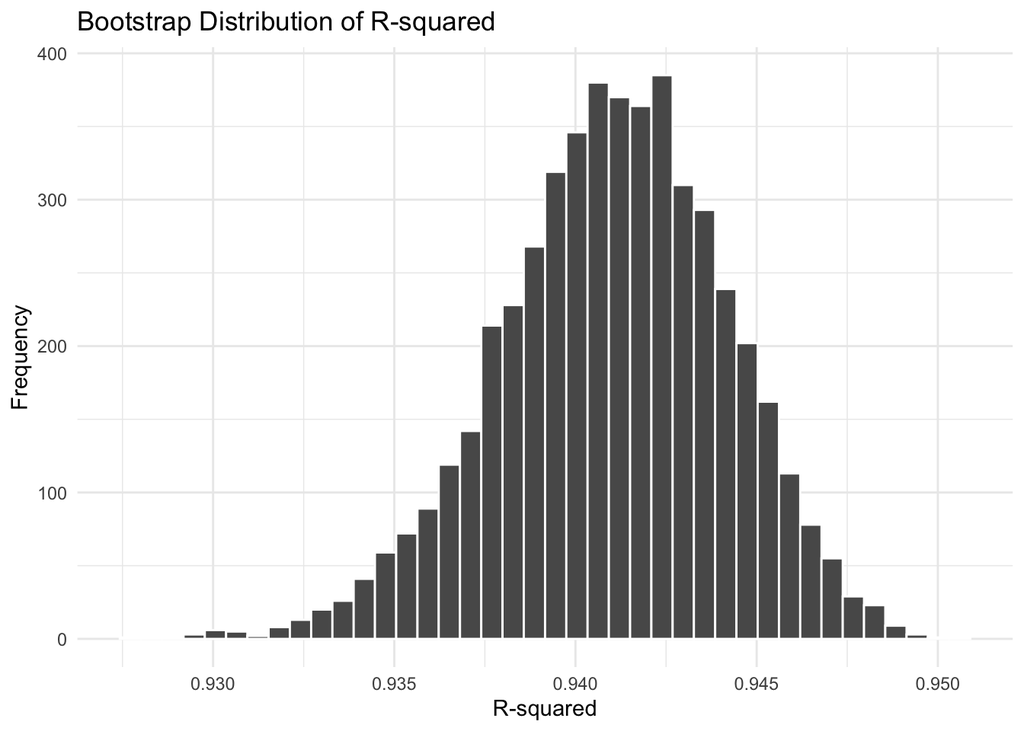

```r
ggplot(boot_results, aes(x = r2)) +
  geom_histogram(bins = 40, color = "white") +
  labs(title = "Bootstrap Distribution of R-squared",
       x = "R-squared",
       y = "Frequency") +
  theme_minimal()
```

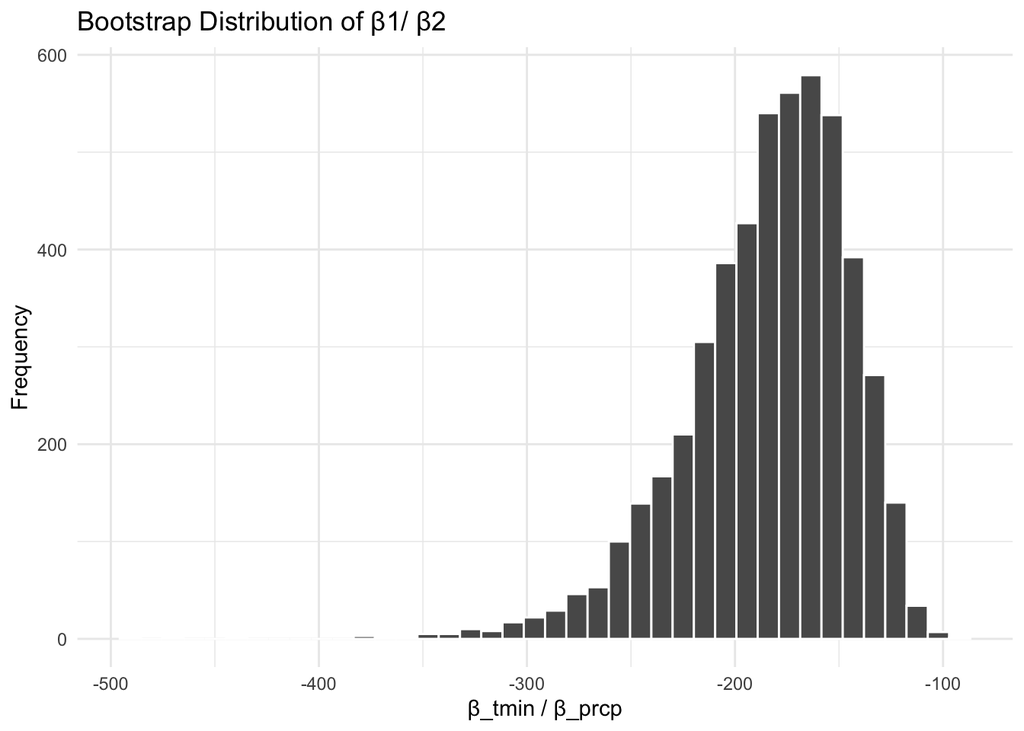

```r
ggplot(boot_results, aes(x = beta_prod)) +
  geom_histogram(bins = 40, color = "white") +
  labs(title = "Bootstrap Distribution of β1/ β2",
       x = "β_tmin / β_prcp",
       y = "Frequency") +
  theme_minimal()
```

The bootstrap distribution of R² roughly symmetric, unimodal and is centered around 0.94. This suggests that the model explains a consistent portion of the variation in tmax. However, the bootstrap distribution of β₁/β₂ is much more skewed to the left.

```r
quantile(boot_results$r2, c(0.025, 0.975))
```

```
##      2.5%     97.5%
## 0.9344540 0.9467628
```

```r
quantile(boot_results$beta_prod, c(0.025, 0.975))
```

```
##      2.5%     97.5%
## -276.3176 -124.6254
```

## Question 3

```r
birthweight =
 read_csv("birthweight.csv", na = c("NA",".", "")) |>
  janitor :: clean_names()
birthweight
```

```
## # A tibble: 4,342 × 20
##    babysex bhead blength   bwt delwt fincome frace gaweeks malform menarche
##      <dbl> <dbl>   <dbl> <dbl> <dbl>   <dbl> <dbl>   <dbl>   <dbl>    <dbl>
##  1       2    34      51  3629   177      35     1    39.9       0       13
##  2       1    34      48  3062   156      65     2    25.9       0       14
##  3       2    36      50  3345   148      85     1    39.9       0       12
##  4       1    34      52  3062   157      55     1    40         0       14
##  5       2    34      52  3374   156       5     1    41.6       0       13
##  6       1    33      52  3374   129      55     1    40.7       0       12
##  7       2    33      46  2523   126      96     2    40.3       0       14
##  8       2    33      49  2778   140       5     1    37.4       0       12
##  9       1    36      52  3515   146      85     1    40.3       0       11
## 10       1    33      50  3459   169      75     2    40.7       0       12
## # ℹ 4,332 more rows
## # ℹ 10 more variables: mheight <dbl>, momage <dbl>, mrace <dbl>, parity <dbl>,
## #   pnumlbw <dbl>, pnumsga <dbl>, ppbmi <dbl>, ppwt <dbl>, smoken <dbl>,
## #   wtgain <dbl>
```

```r
 babies_clean = birthweight |>
  mutate(
    babysex = factor(babysex, levels = c(1,2), labels = c("Male","Female")),
    malform = factor(malform, levels = c(0,1), labels = c("No","Yes")),
    frace = factor(frace,
                   levels = c(1,2,3,4,8,9),
                   labels = c("White","Black","Asian","PuertoRican","Other","Unknown")),
    mrace = factor(mrace,
                   levels = c(1,2,3,4,8),
                   labels = c("White","Black","Asian","PuertoRican","Other"))
  ) |>
  mutate(
    parity = as.integer(parity), bwt = as.numeric(bwt), blength = as.numeric(blength), bhead = as.numeric(bhead), gaweeks = as.numeric(gaweeks), ppbmi = as.numeric(ppbmi), ppwt = as.numeric(ppwt), smoken = as.numeric(smoken), momage = as.numeric(momage), wtgain = as.numeric(wtgain)
  )

 babies_clean
```

```
## # A tibble: 4,342 × 20
##    babysex bhead blength   bwt delwt fincome frace gaweeks malform menarche
##    <fct>   <dbl>   <dbl> <dbl> <dbl>   <dbl> <fct>   <dbl> <fct>      <dbl>
##  1 Female     34      51  3629   177      35 White    39.9 No            13
##  2 Male       34      48  3062   156      65 Black    25.9 No            14
##  3 Female     36      50  3345   148      85 White    39.9 No            12
##  4 Male       34      52  3062   157      55 White    40   No            14
##  5 Female     34      52  3374   156       5 White    41.6 No            13
##  6 Male       33      52  3374   129      55 White    40.7 No            12
##  7 Female     33      46  2523   126      96 Black    40.3 No            14
##  8 Female     33      49  2778   140       5 White    37.4 No            12
##  9 Male       36      52  3515   146      85 White    40.3 No            11
## 10 Male       33      50  3459   169      75 Black    40.7 No            12
## # ℹ 4,332 more rows
## # ℹ 10 more variables: mheight <dbl>, momage <dbl>, mrace <fct>, parity <int>,
## #   pnumlbw <dbl>, pnumsga <dbl>, ppbmi <dbl>, ppwt <dbl>, smoken <dbl>,
## #   wtgain <dbl>
```

```r
proposed_formula = bwt ~ babysex + gaweeks + blength + bhead +
  ppbmi + smoken + parity + momage + wtgain + malform + frace + mrace +
  babysex:gaweeks + babysex:blength

fit_proposed = lm(proposed_formula, data =  babies_clean )

broom::glance(fit_proposed) |>
  print()
```

```
## # A tibble: 1 × 12
##   r.squared adj.r.squared sigma statistic p.value    df  logLik    AIC    BIC
##       <dbl>         <dbl> <dbl>     <dbl>   <dbl> <dbl>   <dbl>  <dbl>  <dbl>
## 1     0.715         0.713  274.      569.       0    19 -30527. 61095. 61229.
## # ℹ 3 more variables: deviance <dbl>, df.residual <int>, nobs <int>
```

```r
broom::tidy(fit_proposed) |>
  print()
```

```
## # A tibble: 20 × 5
##    term                  estimate std.error statistic   p.value
##    <chr>                    <dbl>     <dbl>     <dbl>     <dbl>
##  1 (Intercept)           -5820.     128.     -45.4    0
##  2 babysexFemale           111.     162.       0.684  4.94e-  1
##  3 gaweeks                   9.47     2.00     4.73   2.28e-  6
##  4 blength                  78.8      2.54    31.0    8.01e-191
##  5 bhead                   132.       3.47    38.1    1.27e-273
##  6 ppbmi                     6.88     1.35     5.11   3.43e-  7
##  7 smoken                   -4.64     0.589   -7.88   4.13e- 15
##  8 parity                   90.2     40.8      2.21   2.72e-  2
##  9 momage                    1.77     1.17     1.51   1.31e-  1
## 10 wtgain                    4.13     0.397   10.4    4.76e- 25
## 11 malformYes               -1.49    71.1     -0.0210 9.83e-  1
## 12 fraceBlack               19.7     46.4      0.424  6.71e-  1
## 13 fraceAsian               17.8     69.7      0.255  7.99e-  1
## 14 fracePuertoRican        -53.2     44.9     -1.18   2.37e-  1
## 15 fraceOther              -11.8     74.5     -0.159  8.74e-  1
## 16 mraceBlack             -163.      46.3     -3.51   4.52e-  4
## 17 mraceAsian             -118.      72.3     -1.63   1.03e-  1
## 18 mracePuertoRican        -86.2     45.2     -1.91   5.68e-  2
## 19 babysexFemale:gaweeks     3.93     2.85     1.38   1.67e-  1
## 20 babysexFemale:blength    -4.72     3.31    -1.42   1.54e-  1
```

For this model, I wanted to include fetal size (length, head), maturity (gestational age), sex, maternal resources/behavior (BMI, weight gain, smoking), parity and parental race. I also added two interaction terms (sex × gestational age, sex × length) to allow sex differences in growth trajectories and length–weight mapping.

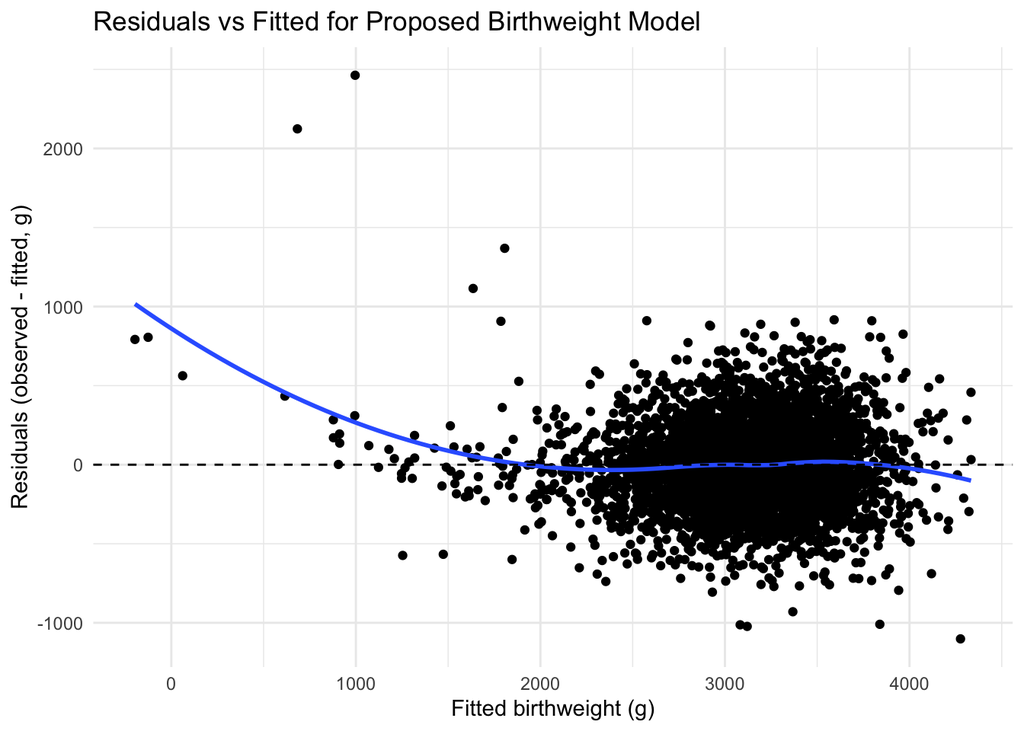

```r
diag_df = babies_clean |>
  add_predictions(fit_proposed, var = "pred") |>
  add_residuals(fit_proposed, var = "resid")

p_resid = ggplot(diag_df, aes(x = pred, y = resid)) +
  geom_point() +
  geom_smooth(method = "loess", se = FALSE) +
  geom_hline(yintercept = 0, linetype = "dashed") +
  labs(title = "Residuals vs Fitted for Proposed Birthweight Model",
       x = "Fitted birthweight (g)",
       y = "Residuals (observed - fitted, g)") +
  theme_minimal()
print(p_resid)
```

```r
modA_formula = bwt ~ blength + gaweeks
modB_formula = bwt ~ bhead * blength * babysex

models = list(
  proposed = proposed_formula,
  model_A = modA_formula,
  model_B = modB_formula
)
```

```r
set.seed(123)
cv_df = crossv_mc(babies_clean, n = 100)

cv_results = cv_df |>
  mutate(
    fits = map(train, ~ map(models, lm, data = as.data.frame(.x)))
  )

cv_results = cv_results |>
  mutate(
    rmse = map2(fits, test, ~ map(.x, function(mod) {
      test_df = as.data.frame(.y)
      pred = predict(mod, newdata = test_df)
      sqrt(mean((test_df$bwt - pred)^2))
    }))
  )
rmse_tidy = cv_results |>
  select(rmse) |>
  unnest_wider(rmse) |>
  pivot_longer(
    cols = everything(),
    names_to = "model",
    values_to = "rmse"
  )

rmse_summary = rmse_tidy |>
  group_by(model) |>
  summarize(
    mean_RMSE = mean(rmse),
    sd_RMSE = sd(rmse),
    .groups = "drop"
  )

rmse_summary
```

```
## # A tibble: 3 × 3
##   model    mean_RMSE sd_RMSE
##   <chr>        <dbl>   <dbl>
## 1 model_A       331.   12.6
## 2 model_B       288.    8.24
## 3 proposed      276.    8.06
```

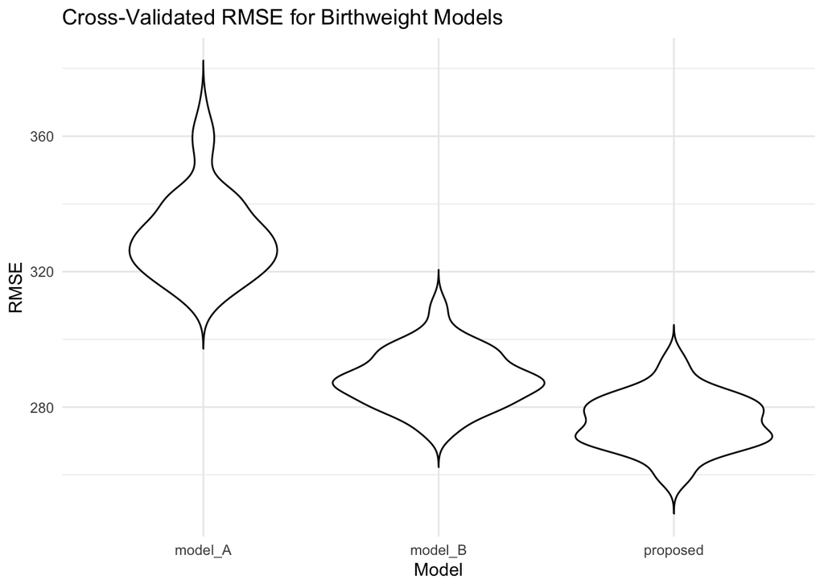

```r
ggplot(rmse_tidy, aes(x = model, y = rmse)) +
  geom_violin(trim = FALSE, color = "black") +
  theme_minimal() +
  labs(
    title = "Cross-Validated RMSE for Birthweight Models",
    x = "Model",
    y = "RMSE"
  )
```